# 多重比較

Week 11 · Part 1

## F 顯著之後，是哪幾組不同？

- 剛孵化的小雞隨機分到不同飼料，六週後量體重。比較酪蛋白、亞麻籽、葵花籽三組，各 12 隻，平均 323.6、218.8、328.9 g。整體 $F(2,33)=14.99$，$p<.001$。
- 三組兩兩比較有 3 對。這類同時處理多項比較的問題稱為**多重比較（multiple comparisons）**。`chickwts` 共有六種飼料；六組兩兩比較有幾對？

$6\times 5/2=15$ 對。**整族錯誤率（familywise error rate, FWER）**是一批比較中至少犯一次**型一錯誤（Type I error）**的機率。

[figure not shown]

曲線假定各虛無假設都成立、檢定彼此獨立。成對比較常共用組別。

IMS 2e §22.5 練習 5（R `chickwts`）；資料共六種飼料，取其中三組比較。IMS §22.2。圖沿用 Week 10 自製示意圖。

## 比較範圍在什麼時候決定？

三組平均為 323.6、218.8、328.9 g。我看完才挑差最大的兩組做檢定。這個 p 值可以當成只考慮一對嗎？

- **事前比較（planned comparison）**依研究問題，在看資料前指定要比哪些組。
- **事後比較（post hoc comparison）**可能用資料選出要報告的組別。挑最大差時，三對都影響了選擇。
- 比較範圍是這三組的 3 個配對。若看完六組平均才挑出三組，選組本身也是資料窺探。

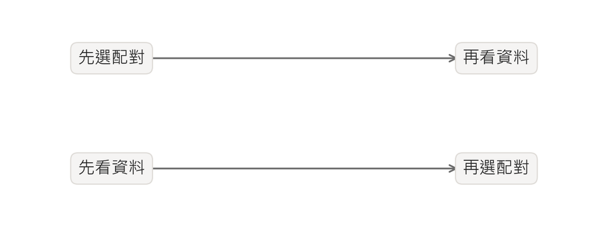

比較決定配對和查看資料的先後。

IMS 2e §22.2（資料窺探，data snooping）；Rosner 8e §12.4，p. 573（事前比較）。資料：IMS §22.5 練習 5。

## 不校正時，哪些平均差超過門檻？

- 用三組共同的組內均方 3,088.4 估計變異數。
- 平均差的標準誤（standard error）約 22.69 g。
- 葵花籽 − 酪蛋白、酪蛋白 − 亞麻籽、葵花籽 − 亞麻籽的平均差為 **5.3、104.8、110.2 g**。先猜哪些差大到不像抽樣變動？

雙尾 $\alpha=.05$ 的門檻約 $2.035\times22.69=46.2$ g。104.8、110.2 g 超過；5.3 g 的原始 $p\approx.82$。

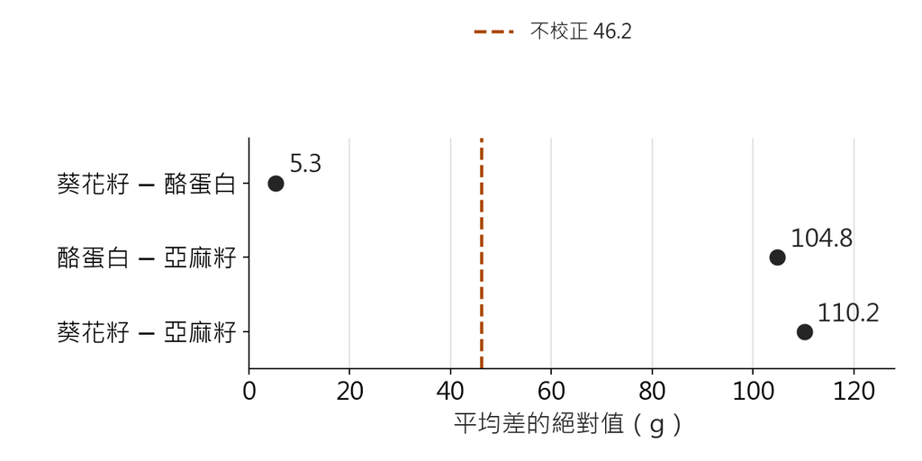

三個點是同一份資料的平均差。門檻線右側的差超過門檻。

IMS 2e §22.5 練習 5（R `chickwts` 三組）；Rosner 8e Eq. 12.12（LSD）。依共同組內均方計算，圖為自製。

## Bonferroni 把 .05 分給每一對

- 三對比較各用 $.05/3\approx.0167$。也可把每個原始 p 乘以 3（上限為 1），校正後再跟 .05 比。
- 同一份飼料資料，平均差與標準誤都不變。現在每一對需要更小的 p 值，平均差門檻會往哪裡移？

**Bonferroni 校正（Bonferroni correction）**把門檻從 46.2 提高到 **57.2 g**。本例仍是 104.8、110.2 g 超過，5.3 g 未超過。

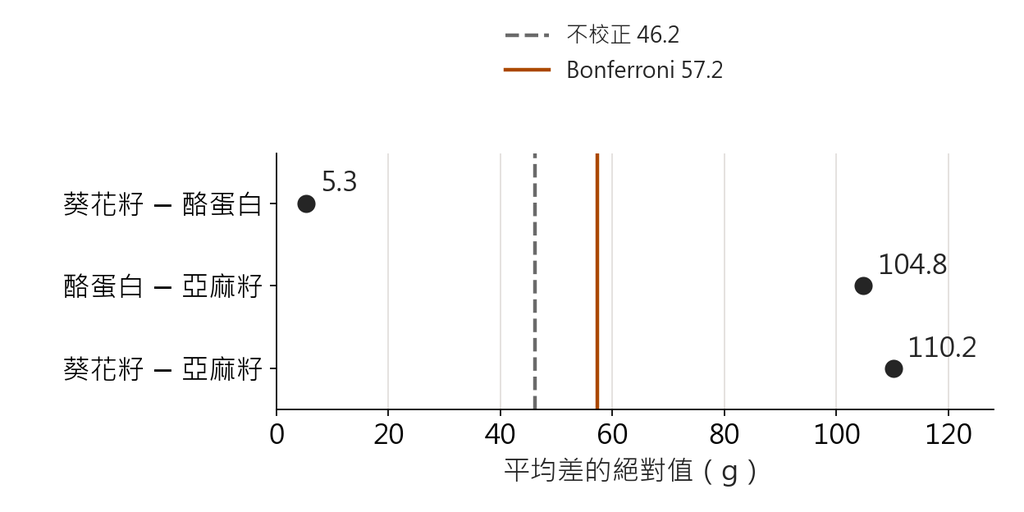

三個點是飼料組的三個平均差。兩條線分別標示未校正與 Bonferroni 門檻。

Rosner 8e Eq. 12.14，p. 571。資料：IMS §22.5 練習 5。自製圖。

## Tukey HSD 怎麼讀一整組區間？

- **Tukey HSD（honestly significant difference）**適用於要比較全部成對差異的情境。
- **95% 同時信賴區間（simultaneous confidence intervals）**以整批區間一起涵蓋各真實差為目標。
- 本例每個區間為「平均差 **± 55.67 g**」。區間不含 0，等同平均差的絕對值超過 55.67 g。
- 葵花籽組比酪蛋白組平均重 5.33 g。這個區間支持什麼結論？

Tukey 區間 −50.34 到 61.00 含 0（$p=.97$），資料不足以判定兩組母體平均不同。未校正區間 −40.83 到 51.49 也含 0，本例判斷不變。

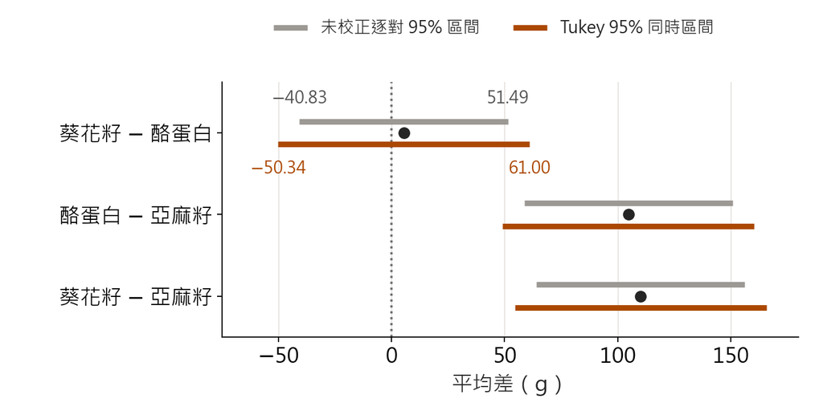

平均差不變；Tukey 同時區間比逐對區間更寬。比較第一對灰、橘區間的兩端與零線的位置。

單因子 Tukey HSD 依 R stats `TukeyHSD` 計算（Rosner 8e §12.10 的 Tukey 例屬混合模型，不直接套用）。資料：IMS §22.5 練習 5。自製圖。

## Tukey 的 55.67 g 怎麼算？

- 若平均差最大的一對都沒超過門檻，其他各對一定也沒超過。Tukey 只要控制「最大平均 − 最小平均」。
- 這個差除以 $\sqrt{\text{MSE}/n}$ 稱為**學生化全距（studentized range）**，記為 $q$。它的分布由組數 $k$ 與組內均方（MSE）的自由度決定，不是 t 分布。

$$\begin{gathered}
s_q = \sqrt{3088.43/12}\approx16.0427 \\
q_{.95;\,3,\,33} \approx 3.47019
\end{gathered}$$

$$\begin{aligned}
\text{HSD} &= q_{.95;\,3,\,33}\times s_q \\
&\approx 55.67\ \text{g}
\end{aligned}$$

成對 t 的標準誤是 $\sqrt2\,s_q=22.69$ g，所以 Tukey 門檻約是 $3.47019/\sqrt2\approx2.45$ 個標準誤；不校正只要 2.035 個。

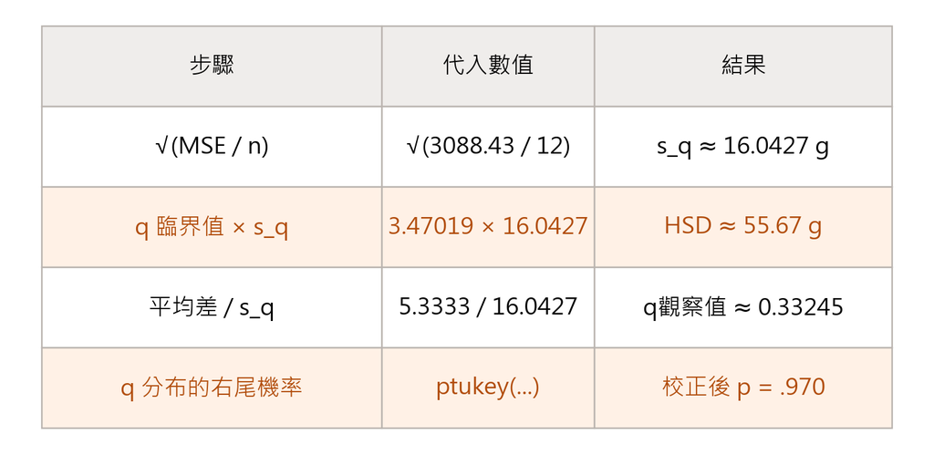

由上往下四列：先算 $s_q$，乘上臨界值得到 HSD；同一個 $s_q$ 也用來算一對的 q 與校正後 p。

R stats `TukeyHSD`、`qtukey`（`nmeans` 是組數，不是總人數）。資料：IMS 2e §22.5 練習 5。

## 提高門檻，有什麼代價？

| 三種飼料 | 門檻（g） |
| --- | --- |
| 不校正 | 46.2 |
| Tukey HSD | 55.7 |
| Bonferroni | 57.2 |

這份資料三對的判斷都沒改變。若母體真有差異，提高門檻後，它更容易被看見還是被漏掉？

圖上的 5.3、104.8、110.2 是這一次樣本的平均差。重複抽樣時樣本差會上下變動；門檻愈高，跨不過門檻的比例愈大。其他條件固定時，**型二錯誤（Type II error）**的機率增加，**檢定力（power）**下降。

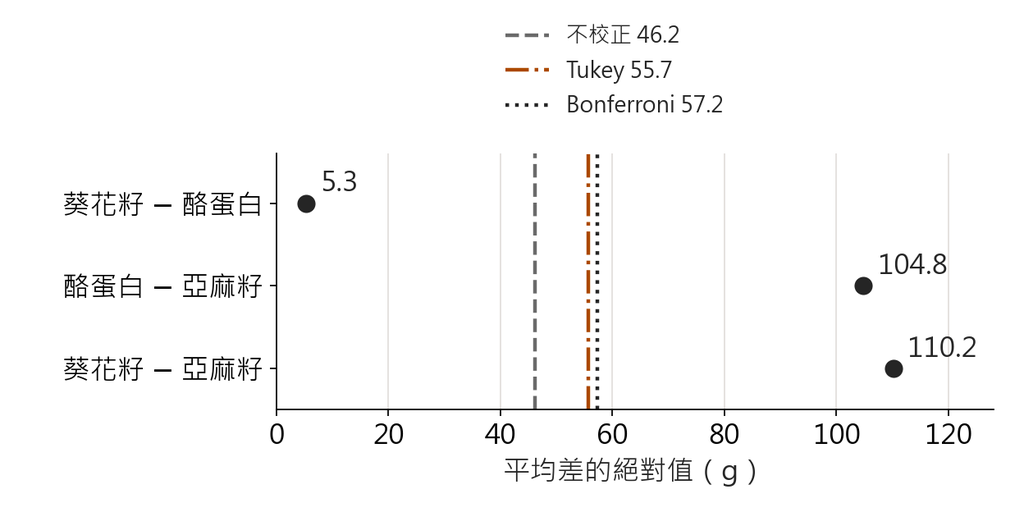

三條門檻放回同一條軸。三個點的位置始終不變。

Rosner 8e §12.4，p. 573。資料：IMS §22.5 練習 5。自製圖。

## Holm：依排序逐關判斷

**Holm 法（Holm method）**也控制整族錯誤率。先將原始 p 由小到大排序；本例依序是平均差 110.2、104.8、5.3 g。

| 關卡 | p 值比較基準 | 平均差門檻 |
| --- | --- | --- |
| 1 | .05／3 | 57.2 |
| 2 | .05／2 | 53.3 |
| 3 | .05 | 46.2 |

前一關通過才往下。110.2、104.8 通過，5.3 未通過，**在此停止拒絕**。Holm 沒有一條適用所有比較的固定門檻。

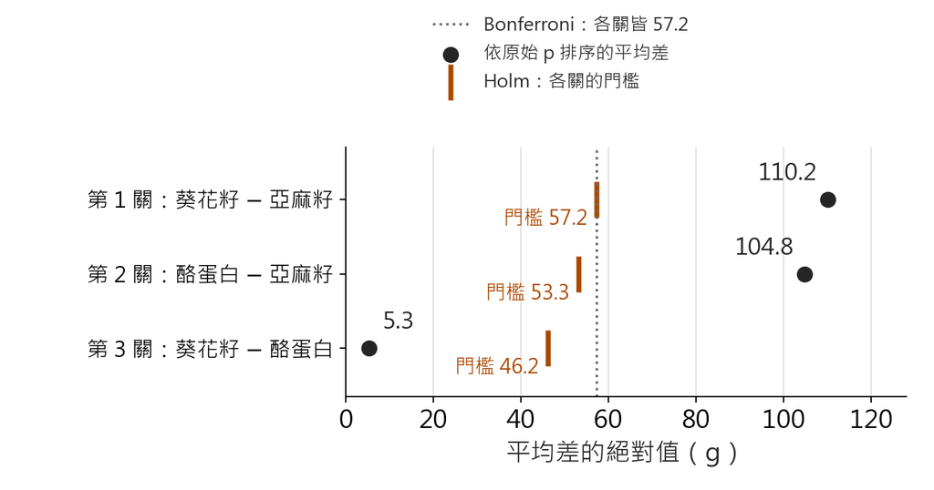

每個點只和自己那一關的橘色門檻比較；灰線為 Bonferroni 的固定門檻。

Holm 法依 R stats `p.adjust`，門檻由 R 重算。資料：IMS §22.5 練習 5。自製圖。

## 練習｜哪一對會因方法改變判斷？

- 高血壓病人隨機分到四組諮詢，每組 20 人，記錄一個月後舒張壓（diastolic blood pressure, DBP）的下降量。
- 四組摘要改編自 Rosner，將「僅減重」組平均由 5.3 改為 6.4。$F(3,76)=5.02$，$p=.003$。
- 先從圖上列出六對平均差的絕對值。哪一對超過未校正的 3.97 與 Tukey 的 5.23 mmHg，卻沒超過 Bonferroni 的 5.40 mmHg？

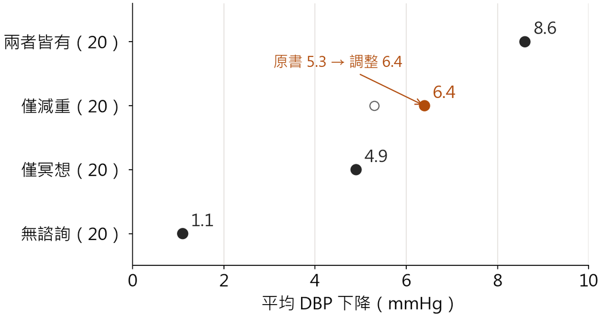

比較四個平均點之間的距離。數值越大，表示 DBP 下降越多。

教學調整資料，改編自 Rosner 8e Table 12.33（p. 622，書中假設情境）：僅減重組平均 5.3 改為 6.4，SD 與人數不變；非課本原始數字或個別資料。F 與門檻依摘要計算；自製圖。

## 同一個 5.3 mmHg，各方法為什麼判斷不同？

六個絕對差為 7.5、5.3、3.8、3.7、2.2、1.5。**僅減重 − 無諮詢 = 5.3**，落在 Tukey 5.23 與 Bonferroni 5.40 之間。

| 方法 | 這一對的 p |
| --- | --- |
| 不校正 | .0095 |
| Tukey | .046 |
| Holm | .048 |
| Bonferroni | .057 |

Holm 第 1 關 7.5 對 5.40 通過；第 2 關 5.3 對 5.27 通過；第 3 關 3.8 對 5.10 未通過，在此停止。三種校正都控制整族錯誤率，判斷仍可能不同。Holm 不比 Bonferroni 保守；Tukey 與 Holm 沒有固定的大小順序。所以方法要在看資料前決定。

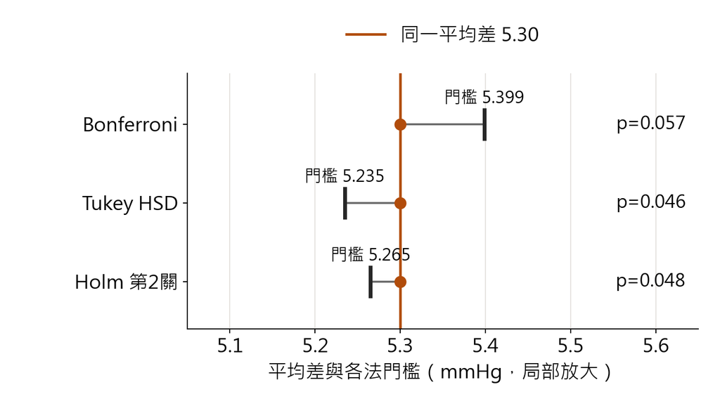

局部放大：同一個平均差 5.3，和三種方法的門檻比較。

教學調整資料，改編自 Rosner 8e Table 12.33；Bonferroni 依 Rosner Eq. 12.14；單因子 Tukey 與 Holm 依 R stats 計算。依摘要計算；自製圖。

## 整體 F 顯著，一定會有一對顯著嗎？

- 依母親吸菸習慣分四組，比較嬰兒出生體重。
- 整體 $F(3,21)=3.256$，$p=.042$。在 $\alpha=.05$ 時，能保證至少有一對通過校正後的門檻嗎？

**不能保證。** 差最大的一對原始 p 約 .0144，乘以六約 .0866，Bonferroni 校正後 p 顯示為 .087；Tukey 校正後 p 為 .064。四組人數不等，各對標準誤不同，所以比較校正後 p，不畫共用門檻。

圖上呈現兩組較高、兩組較低的型態。整體 F 一次考慮四組平均的偏離；每一對只比較兩組，還要控制整批比較的誤報。

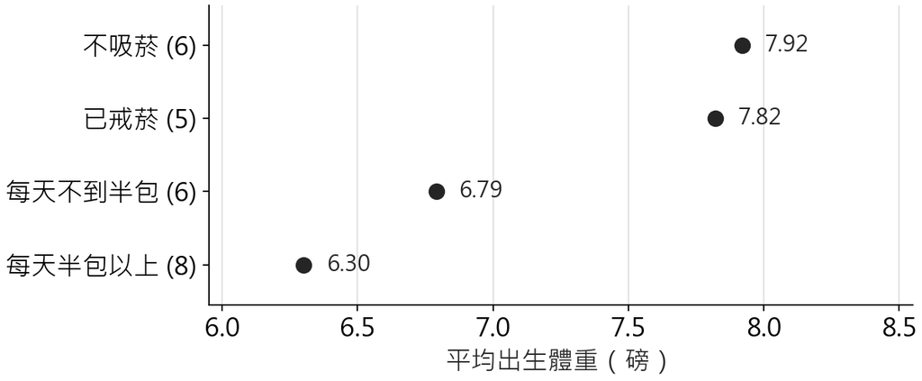

點是各組平均出生體重，括號為人數。橫軸從約 6 磅起，不從 0 起。

資料出自 Pagano & Gauvreau（2000）第 12 章。自製圖。

## 差最大的那一對，p 值怎麼來？

- 不吸菸組減每天半包以上組，未四捨五入的平均差約 1.613 磅。
- 四組共同的組內均方約 1.254，兩組樣本數為 6 和 8。

$$\begin{aligned}
t &\approx \frac{1.613}{\sqrt{1.254(1/6+1/8)}} \\
&\approx 2.667
\end{aligned}$$

用 $df=25-4=21$ 得雙尾 $p\approx.0144$。Bonferroni 對六個配對校正後約 .087。

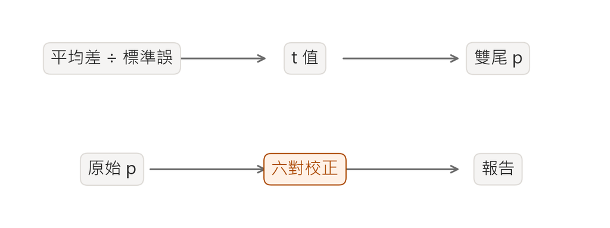

先算一對的雙尾 p，再對整批六對校正。

Rosner 8e Eq. 12.12、12.14。以未四捨五入差計算，顯示值為近似。

## 也可以控制誤報所占的比例

一批檢定中，$V$ 是誤報數（虛無假設為真卻被拒絕），$R$ 是宣告顯著的總數。

| 控制目標 | 定義 |
| --- | --- |
| 整族錯誤率（FWER） | $\Pr(V\ge1)$：至少誤報一次的機率 |
| 偽發現率（false discovery rate, FDR） | $E\!\left[V/\max(R,1)\right]$：重複研究時，誤報比例的平均 |

一次研究中的 $V/\max(R,1)$ 稱為**誤報比例（false discovery proportion, FDP）**。圖中三種情況的 FDP 是 0、.10、.05，平均 .05 就是 FDR；三種結果中有兩種至少誤報一次，FWER = 2/3。真實資料不知道哪些虛無假設為真，算不出這一次的 $V$。FDR 控制在 .05，不表示這次一定有 5% 是誤報，也不是每個顯著結果為假的機率。

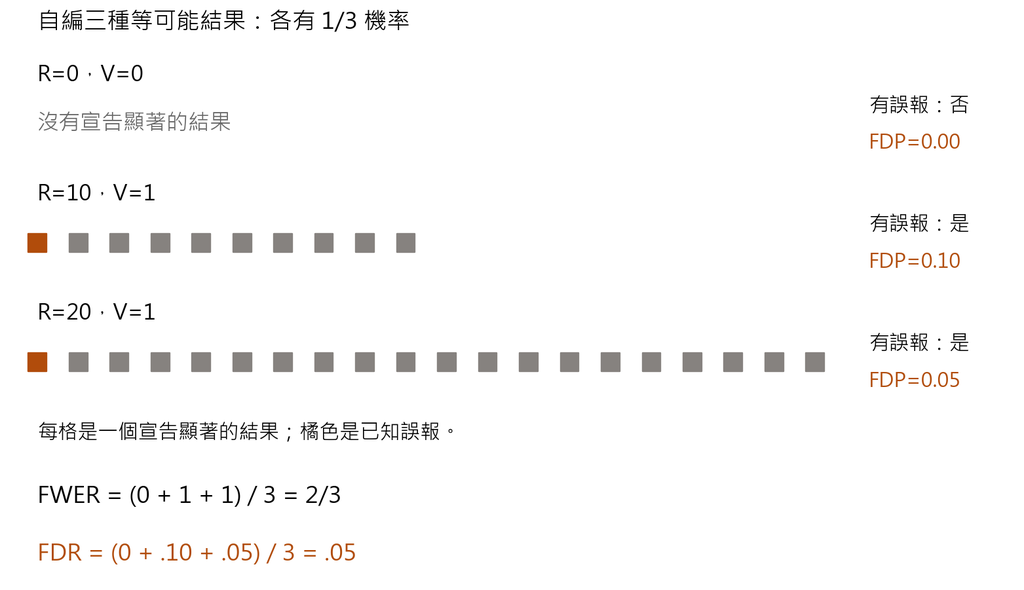

自編情境：三種結果出現機率各 1/3。每列寫出宣告顯著數 R 與誤報數 V。

Rosner 8e §12.4，p. 577（FDR，Benjamini & Hochberg）。自製圖。

## BH 法：找最後一個通過門檻的序號

使用 **Benjamini–Hochberg 法（BH）**時，先將六個原始 p 值由小到大排序，再把第 $i$ 個 p 值與 $(i/6)\times q$ 比較。$q=.05$ 是 FDR 目標，和 Tukey 的 $q$ 無關。

| $i$ | 差 | 原始 p | 門檻 |
| --- | --- | --- | --- |
| 1 | 7.5 | .00033 | .0083 |
| 2 | 5.3 | .00954 | .0167 |
| 3 | 3.8 | .0603 | .0250 |
| 4 | 3.7 | .0672 | .0333 |
| 5 | 2.2 | .2731 | .0417 |
| 6 | 1.5 | .4539 | .0500 |

比較門檻時使用未四捨五入的 p 值。

由下往上看：最後一個 p 在門檻以下的是第幾列？

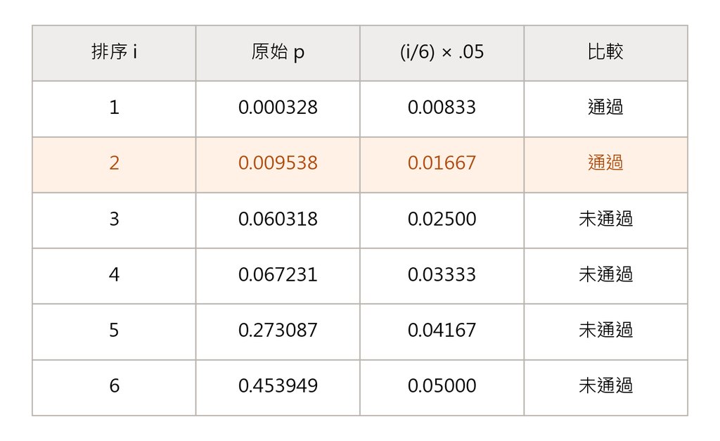

每一列只和自己的門檻比較；第 2 列是最後一個通過的。

第 2 列，拒絕第 1、2 個。BH 是**由下往上（step-up）**：找最大的通過序號，前面某列沒通過也不停。Holm 是**由上往下（step-down）**：第一次沒通過就停止。

Rosner 8e Eq. 12.17，p. 577；教學調整資料改編自 Rosner Table 12.33。依摘要計算；自製圖。

## 為什麼 BH 的門檻隨排名升高？

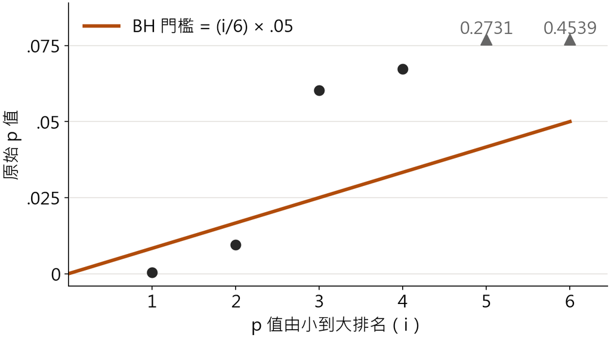

橫軸是 p 值排名。圓點是原始 p 值，橘線是 BH 門檻，三角形標出超出縱軸範圍的數值。

**從右往左找，第一個落在斜線上或下方的點排第幾？**

第 **2** 名。共同門檻是 $.05\times 2/6\approx.0167$，所以拒絕前兩項。

固定門檻 $t$ 時，$m$ 項檢定的預期誤報數至多 $mt$。若預計拒絕 $k$ 項，斜線把門檻設成 $qk/m$，讓這個上界除以 $k$ 後等於 $q$。

實際的 $k$ 由資料決定。檢定彼此獨立時，BH 定理保證重複研究的平均誤報比例不超過 $q$。

[Benjamini & Hochberg（1995）§3.1–3.2](https://doi.org/10.1111/j.2517-6161.1995.tb02031.x)。自製圖，六個 p 值依改編自 Rosner 8e Table 12.33 的教學資料計算。

## BH 校正後 p：乘 6/i，再往上取最小

- 第 $i$ 列先乘 $6/i$。
- 從最後一列往上取**累積最小值**，上限 1，再放回原本順序。

| $i$ | 原始 p | $\frac{6}{i}\,p$ |
| --- | --- | --- |
| 1 | .00033 | .0020 |
| 2 | .00954 | .0286 |
| 3 | .0603 | .1206 |
| 4 | .0672 | .1008 |
| 5 | .2731 | .3277 |
| 6 | .4539 | .4539 |

校正時使用未四捨五入的 p 值。

第 3 列的 BH p 是多少？

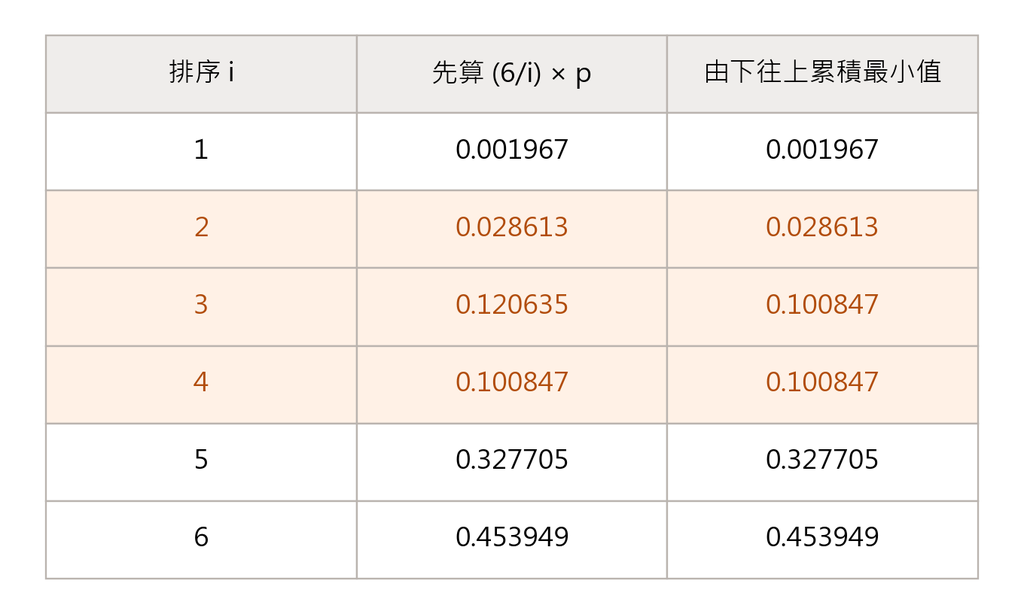

右欄是由下往上取累積最小值的結果；第 3 列由 .1206 變成 .1008。

.1008，因為下一列的 .1008 比 .1206 小。第 1、2 列的 BH 校正後 p 值都 ≤ .05，與門檻法的判斷一致。5.3 mmHg 那對 BH p = .029，控制 FDR；Bonferroni .057、Holm .048、Tukey .046 控制 FWER。目標不同，不能把 BH 看成較寬鬆的 FWER 方法。BH 在檢定獨立或適當正相依時才保證控制 FDR。

Rosner 8e Eq. 12.17，p. 577（$q_i=kp_i/i$，再取其後各列的最小值）；上限 1 與放回順序依 R stats `p.adjust`。教學調整資料；自製圖。

## 先定比較範圍，再寫結果

| 研究問題 | 可以考慮的方法 |
| --- | --- |
| 比較全部成對差異 | Tukey HSD |
| 比較一批預先指定的配對 | Holm 或 Bonferroni |
| 同時探索大量假設 | 依研究目的考慮控制 FDR |

「事先決定以 Tukey 比較四組的全部六對：僅減重組比無諮詢組平均多降 5.3 mmHg，校正後 $p=.046$。」

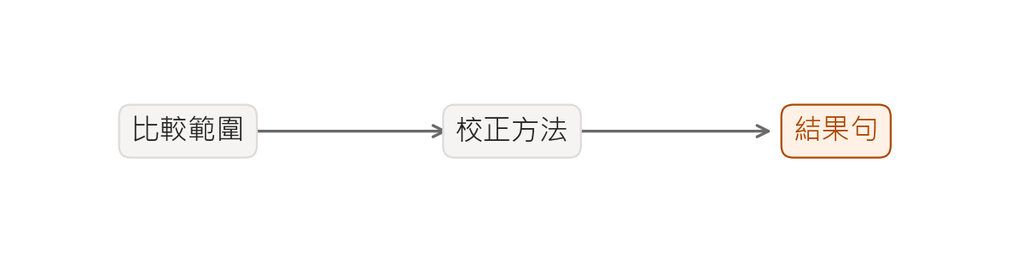

完整的結果句同時交代比較範圍、方法與數值。

Rosner 8e §12.4；結果句用教學調整資料（改編自 Table 12.33，僅減重組平均改為 6.4）；單因子 Tukey 依 R stats `TukeyHSD` 計算。

## Slido｜Part One

[figure not shown]

Slido QR code

https://app.sli.do/event/pEcUD1Jb57Wwf9Ujw3bQRH